# Deer Reproduction & Disease Control: Statistical Analyses

*Damian Satterthwaite-Phillips*

### Getting Started

```r
# Clean the workspace, load libraries and data
rm(list = ls())
library(gam)

deer = read.csv('~/Desktop/NewDeer/Data/Fetus_Final.csv')
head(deer)
```

```
##      earTag sex1  cr1    wt1 sex2  cr2    wt2 sex3 cr3 wt3 sex4 cr4 wt4
## 1 08BCM2142    F 23.5 379.15    M 23.7 364.10 <NA>  NA  NA <NA>  NA  NA
## 2 08BCM2145    M 22.0 288.52    F 24.0 292.92 <NA>  NA  NA <NA>  NA  NA
## 3 08BCM2168    F 23.5 265.92 <NA>   NA     NA <NA>  NA  NA <NA>  NA  NA
## 4 08BCM2169    M  8.5   6.39 <NA>   NA     NA <NA>  NA  NA <NA>  NA  NA
## 5 08BCM2250    M  6.1   6.32 <NA>   NA     NA <NA>  NA  NA <NA>  NA  NA
## 6 12RCL1052    M 10.5  36.94    M 11.0  40.96 <NA>  NA  NA <NA>  NA  NA
##   sex5 cr5 wt5 wtTotal crTotal fetusNo  wtMean crMean year crNo wtNo
## 1   NA  NA  NA  743.25    47.2       2 371.625  23.60 2008    2    2
## 2   NA  NA  NA  581.44    46.0       2 290.720  23.00 2008    2    2
## 3   NA  NA  NA  265.92    23.5       1 265.920  23.50 2008    1    1
## 4   NA  NA  NA    6.39     8.5       1   6.390   8.50 2008    1    1
## 5   NA  NA  NA    6.32     6.1       1   6.320   6.10 2008    1    1
## 6   NA  NA  NA   77.90    21.5       2  38.950  10.75 2012    2    2
##   maleNo femaleNo age2011_12 ageStandard age3categories age7num ageTrinary
```

[output cut: 34 more lines]

### Description of variables

- earTag: unique identifier for does
- sex1, sex2…: sex of each fetus
- cr1, cr2…: crown-rump length for each fetus
- wt1, wt2…: mass of each fetus
- wtTotal, crTotal: total mass or cr of all fetuses in the litter
- fetusNo: number of fetuses detected
- wtMean, crMean: mean mass or cr of all fetuses in a litter
- year: year doe was killed
- crNo, wtNo: number of cr or wt measurements available in a litter
- maleNo, femaleNo: number of male or female fetuses in a litter
- age*: there are several methods for age estimation, only “age3categories” is used, with the categories “fawn”, “yearling”, and “adult”
- pregnant: 1 if fetuses detected, otherwise 0
- killDate: date doe was culled (dd-Mon-yy)
- days: the previous two columns are numeric representations of the date; days is such that it counts days from the beginning of the year (e.g. 1 = Jan 1), regardless of the year
- township, section: locations (see text)
- townshipTotalYrs: total number of years that sharpshooting (SS) occurred in the township
- townshipYTD: number of years that SS occured in the township up to the date in question
- townshipEffort: cumulative number of does killed in the township to date
- townshipIntensity: see text
- section*: same as township stats, but at the section level
- cwdStatus: indicates if the doe was positive or negative for chronic wasting disease

```r
# Rename some of the variables to make code less verbose
names(deer)[29] = 'age' # age refers to categorical: fawn, yearling, adult
names(deer)[46] = 'intensity' # intensity refers to section intensity
names(deer)[50] = 'cwd'
```

### Fetus Detection

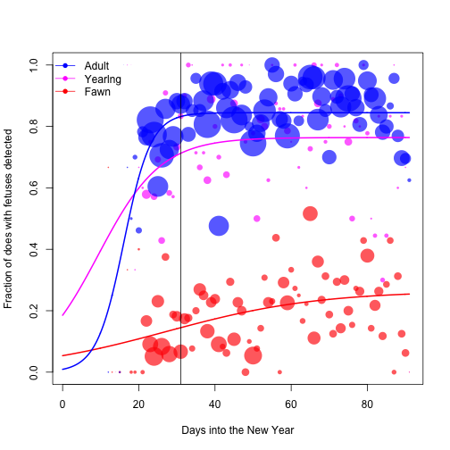

```r
# First structure data so that we have the counts not-pregnant and pregnant
# for each age class
fPregDays.t = table(deer$days[deer$age == 'fawn'],
                    deer$pregnant[deer$age == 'fawn'])
yPregDays.t = table(deer$days[deer$age == 'yearling'],
                    deer$pregnant[deer$age == 'yearling'])
aPregDays.t = table(deer$days[deer$age =='adult'],
                    deer$pregnant[deer$age == 'adult'])

# Add an additional column = fraction pregnant at each day
fPregDays.t = cbind(fPregDays.t,
                    fPregDays.t[,2] / (fPregDays.t[,1] + fPregDays.t[,2]))
colnames(fPregDays.t)[3] = 'FractionPregnant'

yPregDays.t = cbind(yPregDays.t,
                    yPregDays.t[,2] / (yPregDays.t[,1] + yPregDays.t[,2]))
colnames(yPregDays.t)[3] = 'FractionPregnant'

aPregDays.t = cbind(aPregDays.t,
                    aPregDays.t[,2] / (aPregDays.t[,1] + aPregDays.t[,2]))
colnames(aPregDays.t)[3] = "FractionPregnant"

fDays = as.numeric(rownames(fPregDays.t))
yDays = as.numeric(rownames(yPregDays.t))
aDays = as.numeric(rownames(aPregDays.t))

# Plot with point sizes scaled to reflect the number of data contributing
plot(fDays, fPregDays.t[, 3], xlim = c(1, 91), ylim = c(0, 1),
     xlab='Days into the New Year',
     ylab='Fraction of does with fetuses detected',
     cex = (fPregDays.t[, 1] + fPregDays.t[, 2]) / 10,
     pch = 16, col = rgb(1, 0, 0, 0.66))
points(yDays, yPregDays.t[,3], pch = 16, col = rgb(1, 0, 1, 0.66),
       cex = (yPregDays.t[, 1] + yPregDays.t[, 2]) / 10)
points(aDays, aPregDays.t[,3], pch = 16, col = rgb(0, 0, 1, 0.66),
       cex = (aPregDays.t[, 1] + aPregDays.t[, 2]) / 10)

# Fit sigmoid curve: y = L / (1 + C * exp(-k*(x - d)));
# L: limit (capacity); C = time to L; k = steepness; d = displacement
pregDaysF.nls = nls(fPregDays.t[, 3] ~
                    a*(exp(b*fDays - c) / (1+exp(b*fDays-c))),
                    start = list(a = 0.2, b = 1, c = 20),
                    weights = fPregDays.t[, 1] + fPregDays.t[, 2])
#summary(pregDaysF.nls)
A = coef(pregDaysF.nls)[1]
B = coef(pregDaysF.nls)[2]
CC = coef(pregDaysF.nls)[3]

xv = seq(0, 91, 0.1)
yv = A*(exp(B*xv - CC) / (1 + exp(B*xv - CC)))
lines(xv, yv, col = 2, lwd = 2)

# Because the last few yearling data have unusually low proportions, if we
# fit the function as is, we get a graph that begins at the asymptote, and
# drops to 0 at the far right. To force an increasing fit we remove the
# smallest number of data points possible (2) from the right.
yPregDays.t2 = yPregDays.t[-c(77:78), ]
pregDaysY.nls = nls(yPregDays.t2[, 3] ~
                    a*(exp(b*yDays - c) / (1 + exp(b*yDays - c))),
                    start = list(a = 0.73, b = 0.08, c = 5),
                    weights = yPregDays.t2[, 1] + yPregDays.t2[, 2])
#summary(pregDaysY.nls)
A = coef(pregDaysY.nls)[1]
B = coef(pregDaysY.nls)[2]
CC = coef(pregDaysY.nls)[3]
yv = A*(exp(B*xv - CC) / (1 + exp(B*xv - CC)))
lines(xv, yv, col = 6, lwd = 2)

pregDaysA.nls = nls(aPregDays.t[, 3] ~
                    a*(exp(b*aDays - c) / (1 + exp(b*aDays - c))),
                    start = list(a = 0.8, b = 1, c = 19),
                    weights = aPregDays.t[, 1] + aPregDays.t[, 2])
#summary(pregDaysA.nls)
A = coef(pregDaysA.nls)[1]
B = coef(pregDaysA.nls)[2]
CC = coef(pregDaysA.nls)[3]
yv = A*(exp(B*xv - CC) / (1 + exp(B*xv - CC)))
lines(xv, yv, col = 4, lwd = 2)
legend('topleft', pch = 16, lty = 1, col = c(4, 6, 2),
       legend=c('Adult', 'Yearlng', 'Fawn'), bty = 'n')

abline(v = 31)
```

The 31-day mark (Jan 31; vertical black line) was somewhat arbitrarily chosen as the day after which fetuses become reliably detectable (e.g., where the fitted functions begin to level off). Hence we omit data prior to this date as it may bias the data toward artificially low pregancy rates.

```r
deerF1 = subset(deer, days > 31)
```

### Fetal Size and Growth

Next we examine metrics for the fetus sizes.

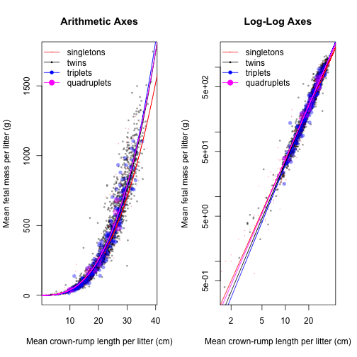

```r
# Examining fetal growth:
singles = lm(log(wtMean[fetusNo == 1]) ~ log(crMean[fetusNo == 1]), deer)
twins = lm(log(wtMean[fetusNo == 2]) ~ log(crMean[fetusNo == 2]), deer)
triplet = lm(log(wtMean[fetusNo == 3]) ~ log(crMean[fetusNo == 3]), deer)
quadq <- lm(log(wtMean[fetusNo == 4 | fetusNo == 5]) ~
            log(crMean[fetusNo == 4 | fetusNo == 5]), deer)



par(mfrow = c(1, 2))
plot(wtMean[fetusNo == 2] ~ crMean[fetusNo == 2],
     xlab = 'Mean crown-rump length per litter (cm)',
     ylab = 'Mean fetal mass per litter (g)',
     col = rgb(0, 0, 0, 0.4), pch = 16, cex = 0.5,
     data = deer, main = 'Arithmetic Axes')
points(wtMean[fetusNo == 1] ~ crMean[fetusNo == 1], cex = 0.25, pch = 16,
      col = rgb(1, 0, 0, 0.4), data = deer)
points(wtMean[fetusNo == 3] ~ crMean[fetusNo == 3], pch = 16,
       col = rgb(0, 0, 1, 0.4), data = deer)
points(wtMean[fetusNo == 4 | fetusNo == 5] ~
       crMean[fetusNo == 4 | fetusNo==5], cex = 1.5, pch = 16,
       col = rgb(1, 0, 1, 0.4), data = deer)

xv <- seq(0, 45, 0.01)
yv1 <- exp(coef(singles)[1]) * xv^(coef(singles)[2])
yv2 <- exp(coef(twins)[1]) * xv^(coef(twins)[2])
yv3 <- exp(coef(triplet)[1]) * xv^(coef(triplet)[2])
yv4 <- exp(coef(quadq)[1]) * xv^(coef(quadq)[2])

lines(xv, yv1, col = 2)
lines(xv, yv2)
lines(xv, yv3, col = 4)
lines(xv, yv4, col = 6)
legend('topleft', lty = 1, pch = 16, pt.cex=c(0.25, 0.5, 1, 1.5),
        col = c(2, 1, 4, 6),
        legend=c('singletons', 'twins', 'triplets', 'quadruplets'),
        bty = 'n')

# Rescale with log - log axes
plot(wtMean[fetusNo == 2] ~ crMean[fetusNo == 2],
     xlab = 'Mean crown-rump length per litter (cm)',
     ylab = 'Mean fetal mass per litter (g)',
     col = rgb(0, 0, 0, 0.4), pch = 16, cex = 0.5,
     data = deer, log = c('xy'), main = 'Log-Log Axes')
points(wtMean[fetusNo == 1] ~ crMean[fetusNo == 1], cex = 0.25, pch = 16,
      col = rgb(1, 0, 0, 0.4), data = deer)
points(wtMean[fetusNo == 3] ~ crMean[fetusNo == 3], pch = 16,
       col = rgb(0, 0, 1, 0.4), data = deer)
points(wtMean[fetusNo == 4 | fetusNo == 5] ~
       crMean[fetusNo == 4 | fetusNo==5], cex = 1.5, pch = 16,
       col = rgb(1, 0, 1, 0.4), data = deer)
lines(xv, yv1, col = 2)
lines(xv, yv2)
lines(xv, yv3, col = 4)
lines(xv, yv4, col = 6)
legend('topleft', lty = 1, pch = 16, pt.cex=c(0.25, 0.5, 1, 1.5),
        col = c(2, 1, 4, 6),
        legend=c('singletons', 'twins', 'triplets', 'quadruplets'),
        bty = 'n')
```

The purpose of the above graphics is to demonstrate that the mass has a non-linear relationship with body length. We to create a metric that captures the 'size' of a fetus (e.g., as an indicator of its fitness), but that is constant regardless of its gestation age, so that we can use the same metric for all fetuses regardless. The second graph shows that the log - log relationship between mass is linear, and hence log(mass) / log(crLength) = constant for all gestation ages, though the constant differs for litter size.

We can further investigate this claim by modeling the log(mass) regressed on log(crLength). Here I exemplify with twin litters.

```r
loglog.m  = lm(log(wtMean[fetusNo == 2]) ~ log(crMean[fetusNo == 2]),
               data = deerF1)
summary(loglog.m)
```

```
##
## Call:
## lm(formula = log(wtMean[fetusNo == 2]) ~ log(crMean[fetusNo ==
##     2]), data = deerF1)
##
## Residuals:
##      Min       1Q   Median       3Q      Max
## -1.30508 -0.11304 -0.02224  0.10201  1.28415
##
## Coefficients:
##                           Estimate Std. Error t value Pr(>|t|)
## (Intercept)               -3.06991    0.05045  -60.85   <2e-16 ***
## log(crMean[fetusNo == 2])  2.85969    0.01613  177.34   <2e-16 ***
## ---
## Signif. codes:  0 '***' 0.001 '**' 0.01 '*' 0.05 '.' 0.1 ' ' 1
##
## Residual standard error: 0.1979 on 1723 degrees of freedom
##   (29 observations deleted due to missingness)
## Multiple R-squared:  0.9481, Adjusted R-squared:  0.948
## F-statistic: 3.145e+04 on 1 and 1723 DF,  p-value: < 2.2e-16
```

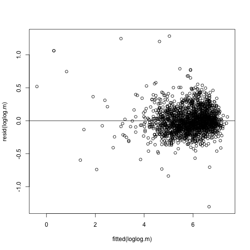

```r
par(mfrow = c(1, 1))
plot(resid(loglog.m) ~ fitted(loglog.m))
abline(h = 0)
```

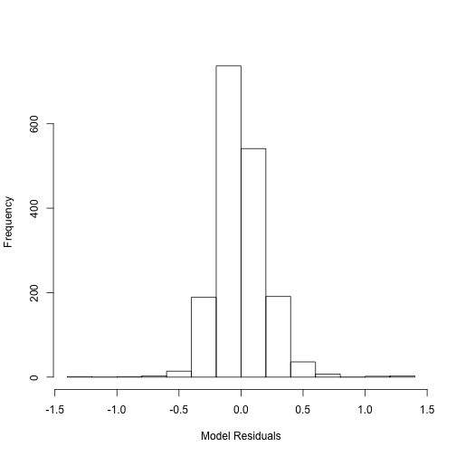

```r
hist(resid(loglog.m), main = '', xlab = 'Model Residuals')
```

Looking at the residuals, we can see that they are normally distributed, with constant variance, so the assumption that the ratio is constant is well-supported.

Now we are ready to begin analysis of the the different reproductive parameters in response to sharpshooting intensity.

Go to the next page

© 2015 Damian Satterthwaite-Phillips